# Tarea 1- Ejercicios 3 y 4

Eliza Zenteno

8/19/2020

```r
library(tidyverse)
```

##Ejercicio 3:

Cargamos el conjunto de datos `iris`.

```r
data(iris3)
```

1. Calcular $\boldsymbol{\bar{x}}$, la matriz de sumas de cuadrados corregida por la media $\boldsymbol{A}$ y la matriz de covarianza insesgada $S_X$.

```r
#3a:
#Cargamos datos de Iris y librerias de manejo de databases
datos <- as.data.frame(iris3)
#Tomamos la matriz con datos correspondientes a la especie Setosa.
X <- as.matrix(datos[,1:4])
m <- nrow(X)
uno <- rep(1,m)

#Calculamos x barra
suma_setosa <- colSums(X)
media_setosa <- suma_setosa/m
names(media_setosa)[] = "Media"

#Calculamos la matriz A
aux <- diag(m)-uno%*%t(uno)/m
A <- t(X) %*% aux %*% X

#Matriz de covarianza muestral insesgada
S_x <- (1/49)*A
```

b)Obtener eigenvalores y eigenvectores de $\boldsymbol{S}$.

```r
spec <- eigen(S_x)
e_valores <- as.vector(spec[[1]])
```

c)Sea $U$ la matrix de eigenvectores de $S$ y $L$ la matriz cuadrada cuyas entradas en la diagonal son los eigenvalores.

```r
U <- as.matrix(spec[[2]]) #matriz de eigenvectores
L <- diag(e_valores,4)
```

Demostramos numéricamente que $\boldsymbol{ULU'}=\boldsymbol{S}$

Para ello calcularemos la norma euclideana de la diferencia de matrices y notemos que dichas cantidades son casi cero.

```r
norm(U%*%L%*%t(U) - S_x)
```

```
## [1] 8.262488e-15
```

Vemos también que $\boldsymbol{ULU'}$ y $\boldsymbol{S}$ son prácticamente iguales.

```r
U%*%L%*%t(U)
```

```
##            [,1]        [,2]        [,3]        [,4]
## [1,] 0.12424898 0.099216327 0.016355102 0.010330612
## [2,] 0.09921633 0.143689796 0.011697959 0.009297959
## [3,] 0.01635510 0.011697959 0.030159184 0.006069388
## [4,] 0.01033061 0.009297959 0.006069388 0.011106122
```

```r
S_x
```

```
##                 Sepal L..Setosa Sepal W..Setosa Petal L..Setosa Petal W..Setosa
## Sepal L..Setosa      0.12424898     0.099216327     0.016355102     0.010330612
## Sepal W..Setosa      0.09921633     0.143689796     0.011697959     0.009297959
## Petal L..Setosa      0.01635510     0.011697959     0.030159184     0.006069388
## Petal W..Setosa      0.01033061     0.009297959     0.006069388     0.011106122
```

Observamos que $\boldsymbol{U'U}=\boldsymbol{UU'}=\boldsymbol{I}_4$.(Se tomó un redondeo de 3 dígitos)

```r
round(U%*%t(U),3)#UU'#
```

```
##      [,1] [,2] [,3] [,4]
## [1,]    1    0    0    0
## [2,]    0    1    0    0
## [3,]    0    0    1    0
## [4,]    0    0    0    1
```

```r
round(t(U)%*%U,3)#U'U
```

```
##      [,1] [,2] [,3] [,4]
## [1,]    1    0    0    0
## [2,]    0    1    0    0
## [3,]    0    0    1    0
## [4,]    0    0    0    1
```

Obtener matriz de gráficas de dispersión de las cuatro variables para cada variedad de iris, todo en la misma gráfica.

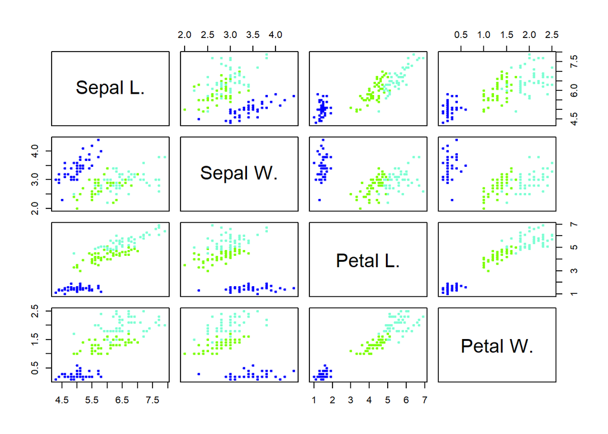

```r
colores <- c("blue", "chartreuse", "aquamarine")
species <- names(iris3[1,1,])
pairs(rbind(iris3[,,1],iris3[,,2],iris3[,,3]),
      col=colores[gl(3,50,labels = species)], pch = 19,  cex = 0.5 )
```

##Ejercicio 4:

Usar los datos del ejercicio anterior.

Considerando $Y=\begin{pmatrix}y_1 & y_2 & y_3 & y_4 & y_5\end{pmatrix}$ donde $y_i$ representa la $i$-ésima columna de $Y$ cuyas primeras cuatro columnas sean las mismas que X y cuya última columna es Petal L. + Petal W. con una matriz $C$ tal que $Y=XC$.

Tomamos $C$ de la forma:
$$C=\begin{pmatrix}1&0&0&0&0\\0&1&0&0&0\\0&0&1&0&1\\0&0&0&1&1\end{pmatrix}$$

[output not shown]

b)Calcular la matriz de covarianzas muestral $S_Y$ y sus eigenvalores y eigenvectores

```r
n <- nrow(Y)
unoY <- rep(1,n)

#Calculamos y barra
sumaY <- colSums(Y)
media_Y <- sumaY/n

#Calculamos la matriz A
auxY <- diag(n)-uno%*%t(uno)/n
A_Y <- t(Y) %*% auxY %*% Y

#Matriz de covarianza muestral insesgada
S_y <- (1/49)*A_Y

#eigenvalores y eigenvectores
(spec_y <- eigen(S_y))
```

```
## eigen() decomposition
## $values
## [1] 2.442194e-01 7.483824e-02 3.305869e-02 1.049178e-02 7.456453e-19
##
## $vectors
##            [,1]        [,2]        [,3]        [,4]          [,5]
## [1,] 0.65694047  0.03846434  0.75289193 -0.01017121  3.463130e-16
## [2,] 0.71184975  0.29542749 -0.63659061 -0.02729311 -2.573590e-16
## [3,] 0.12521671 -0.54795807 -0.08917354 -0.58547201 -5.773503e-01
## [4,] 0.07555878 -0.20605014 -0.04479513  0.78517149 -5.773503e-01
## [5,] 0.20077549 -0.75400821 -0.13396867  0.19969948  5.773503e-01
```

Notemos que el valor más pequeño de los eigenvalores es *cercano* a cero. De la misma forma, la variable `comb_lin` toma la combinación lineal de las columnas de $Y$ cuyos pesos son las entradas del eigenvector correspondiente al eigenvalor más pequeño. Así podemos ver que la varianza de las entradas de `comb_lin` es *casi* cero.

```r
min(spec_y$values)
```

```
## [1] 7.456453e-19
```

```r
comb_lin <- numeric(dim(S_y)[1])
for (i in 1:dim(S_y)[1]) {
  comb_lin <- comb_lin + spec_y$vectors[i,5]*Y[,i]
}
var(comb_lin)
```

```
## [1] 2.336397e-32
```

c)Tambi[en se puede calcular la varianza muestral$S_Y$ a partir de $C'S_XC$. Notemos que la norma euclideana de la diferencia entre las matrices y es *casi* cero.

```r
aprox <- t(C)%*%S_x%*%C
norm(aprox - S_y)
```

```
## [1] 3.400058e-16
```